# Modeling Sporting Match Outcomes Using Markov Chain Monte Carlo

# Generating Player Abilities

In this project, we first generate random samples from the sinh-arcsinh distribution, which exhibits kurtosis and skewness. These samples represent the unobserved abilities of the players in a sporting competition. The sinh-arcsinh distribution has probability density function
$$f_X(x) := \frac{\delta}{(2\pi\sigma^2)^{1/2}} \left(\frac{1+ S_{\epsilon, \delta} (x/\sigma)^2}{1 + (x/\sigma)^2}\right)^{1/2} \exp \left(-\frac{1}{2} S_{\epsilon, \delta}^2 (x/\sigma)\right),$$
$\forall x\in\mathbb{R}$, where $S_{\epsilon, \delta}(z) = \sinh (\epsilon + \delta \sinh^{-1}(z))$ is the sinh-arcsinh transformation. The cumulative distribution function has the form $F_X(x) = \Phi(S_{\epsilon, \delta}(x/\sigma))$, where $\Phi$ is the standard normal CDF. Hence, to generate samples from the sinh-arcsinh distribution, we use the inverse transformation method. If $U \sim \text{Uniform}(0,1)$ and $F$ is the cumulative distribution function of $X$, then $X = F^{-1}(U)$. If $W \sim \text{N}(0,1)$, then $\Phi(W) \sim \text{Uniform}(0,1)$, so we may write $W = S_{\epsilon,\delta}(x/\sigma)$. Solving for $X$ yields the deterministic transformation
$$X = \sigma \sinh \left(\frac{\text{arcsinh} (W) - \epsilon}{\delta}\right).$$

We then perform a Monte Carlo test using the statistic
$$T(\theta) := \left|(d-1)^{-1} \sum \theta_i^3 \right|.$$
This statistic depends on the third moment of the $\theta_i$’s and is therefore sensitive to skewness. We then compute the p-value of this test statistic under the null hypothesis, where the generated samples are assumed to be iid standard normal variables,
$$H_0: \theta_i \overset{\mathrm{iid}}{\sim} N(0,1).$$
The resulting $p$-value is far less than $0.05$, so the generated samples do not appear consistent with an i.i.d. standard normal sample. We therefore have enough evidence to reject the null hypothesis, $H_0$, at the 5% significance level.

# Generating Match Outcomes

We model pairwise match outcomes using the Bradley-Terry model, with results coded as $\{-1,+1\}$. Let $Y_{ij}$ denote the outcome for player $i$ when competing against player $j$. Then the probability that player $i$ wins is
$$\mathbb{P}(Y_{ij} = +1) = \frac{1}{1+\exp{(\theta_j - \theta_i)}}.$$
After modeling the probability of winning, the outcome of each match can then be modeled as a Bernoulli process, with $i$ winning with the probability generated. Since we assume that there are exactly two matches between every pair of athletes, we can then generate the result of a total of $n = d(d-1) = 2450$ matches.

Because the Bradley-Terry model depends only on differences $\theta_i-\theta_j$ for $i \neq j$, the parameterization is not identifiable without an additional constraint. To resolve this structural identifiability issue and improve numerical stability, we impose a sum-to-zero constraint by setting the ability of the 50th player to
$$\theta_d = -\sum_{i=1}^{d-1} \theta_i.$$
This makes $\theta_d$ a derived parameter rather than an independent draw, so exchangeability is lost.

We assume independent sinh-arcsinh prior distributions for each $\theta_j$, for $1 \leq j \leq d-1$, with parameters $\sigma = 10$ and $\epsilon = \delta = 1$. Let
$$\boldsymbol{\theta} = (\theta_1, \ldots, \theta_{d-1}), \quad \theta_d = -\sum_{k=1}^{d-1} \theta_k.$$

The posterior distribution is then proportional to:
$$\pi(\boldsymbol{\theta} \mid \mathbf{y}) \propto L(\boldsymbol{\theta}; \mathbf{y}) \, \pi(\boldsymbol{\theta}).$$

Under the Bradley-Terry model, where $y_r = \{-1, +1\}$, the likelihood function is
$$L(\boldsymbol{\theta}; \mathbf{y})
=
\prod_{r=1}^n
\frac{1}{1 + \exp\left\{-y_r(\theta_{i_r} - \theta_{j_r})\right\}}.$$

Since the prior distributions are independent,
$$\pi(\boldsymbol{\theta})
=
\prod_{j=1}^{d-1} f(\theta_j; 10, 1, 1),$$
where $f(\cdot;10,1,1)$ denotes the sinh-arcsinh density with parameters $\sigma = 10$, $\epsilon = 1$, and $\delta = 1$.

Hence, the posterior distribution can be expressed as
$$\pi(\boldsymbol{\theta} \mid \mathbf{y}) \propto
\left[
\prod_{r=1}^n
\frac{1}{1 + \exp\left\{-y_r(\theta_{i_r} - \theta_{j_r})\right\}}
\right]
\left[
\prod_{j=1}^{d-1} f(\theta_j; 10, 1, 1)
\right].$$

# Markov Chain Monte Carlo Methods

## Random Walk Metropolis and Preconditioned Metropolis-Adjusted Langevin Algorithm

Initially, inspired by Lecture 10, we first considered a standard Metropolis-Adjusted Langevin Algorithm (MALA). In preliminary runs, the standard MALA algorithm was very sensitive to the step size, where small changes in the step size could cause the acceptance rate to move from almost always accepting to almost always rejecting. This made it extremely difficult to find a stable tuning choice. Therefore, we then moved onto a preconditioned version (pMALA) based on an empirical covariance estimate from a RWM chain.

To construct the preconditioner, we first ran a Random Walk Metropolis chain. The RWM chain had an acceptance rate of approximately 0.24, which is close to the usual target for high-dimensional random-walk methods. However, the traceplots showed substantial long-term drift across several coordinates, suggesting slow mixing and poor practical convergence. We therefore chose to discard the fisrt 25% of the chain as burn-in process, and used the post-burn-in samples to estimate the empirical posterior covariance matrix. This covariance matrix was then used to scale the pMALA proposal, with a small diagonal regularization term added for numerical stability. The purpose was to make the proposal better match the scale and dependence structure of the posterior.

After tuning the pMALA step size to $h=0.69$, the pMALA chain achieved an acceptance rate of approximately 0.60 and produced much more stable traceplots, as shown in Figure 1. Despite this improvement, pMALA was computationally expensive. Each iteration required evaluating the gradient of the 49-dimensional log-posterior, and each gradient evaluation involved all 2450 match outcomes together with the sum-to-zero constraint. It takes roughly 1 minute to run through the entire RWM and pMALA program with 15000 iterations. Therefore, pMALA was apparently not the most practical choice for the final posterior analysis.

## Adaptive Metropolis Algorithm

Inspired by the content of Tutorial 9, we tried to implement an Adaptive Metropolis algorithm (AM). AM is a random-walk Metropolis method in which the proposal covariance is updated during the run using the empirical covariance of the previous samples. This allows the proposal to gradually adapt to the scale and dependence structure of the posterior distribution, rather than relying on a fixed isotropic proposal.

In the implementation, the proposal covariance matrix was updated as
$$C_t =
\begin{cases}
C_0, & t \leq t_0, \\
s_d \operatorname{cov}(X_0,\ldots,X_{t-1}) + \epsilon I_d, & t > t_0,
\end{cases}$$
where $C_0$ is the initial scaled identity covariance matrix, $t_0=10000$ delays adaptation at the beginning of the chain, $s_d$ controls the proposal scale, and $\epsilon I_d$ is a small diagonal regularization term added for numerical stability. The delay is useful because the empirical covariance estimate is unstable during the early iterations, when the chain may still be far from the main posterior region.

As suggested by the paper, the common guideline for high-dimensional random-walk Metropolis algorithms is to scale the empirical covariance by approximately $2.4^2/d$, where $d$ is the dimension of the target distribution. This result, however, is motivated by optimal-scaling theory for approximately multivariate Gaussian targets and Gaussian proposals. However, in our case the posterior is not expected to be close to a simple multivariate normal distribution, partly because the generated abilities are non-normal and the Bradley-Terry likelihood imposes nonlinear dependence between parameters. Therefore, we treated this scaling rule as a starting point and tuned the scale empirically using the acceptance rate and traceplots.

After tuning, we used a scale value of 2.7 for the final AM run. This gave an acceptance rate of approximately 0.26, close to the usual high-dimensional random-walk target of 0.234. We ran the chain for 300000 iterations and discarded the first 100000 as burn-in. Compared with pMALA, AM was much faster computationally because it did not require gradient evaluations at every iteration. In our implementation, the AM run completed 300000 iterations in around 40 seconds, whereas pMALA required around one minute for only 15000 iterations.

The post-burn-in traceplots, as shown in Figure 2, and running posterior means suggest that the AM chain converged reasonably well after burn-in. As shown in Figure 3, the running means showed no clear long-term drift and stabilized at values very similar to those produced by pMALA. This provides evidence that the AM chain was sampling from the same posterior region, while avoiding the expensive gradient calculations required by pMALA. The post-burn-in effective sample sizes ranged from about 1341 to 1966, with a mean of about 1656, suggesting an adequate number of effectively independent samples for posterior summaries, although some autocorrelation remained.

To assess whether the model recovered the simulated abilities, we compared the posterior mean estimates with the true latent abilities. The posterior means were mostly negative and did not perfectly recover the raw simulated ability values. Similarly, the marginal credible intervals computed from the AM samples only covered around 24.5% of the raw simulated ability values, suggesting that uncertainty in the absolute ability levels was not perfectly predicted.

However, in the Bradley-Terry model, win probabilities depend only on differences between abilities, not their absolute location. After centering both the true abilities and posterior mean estimates, the points in Figure 4 closely followed the line $y=x$. This indicates that, although the raw ability values were not recovered exactly, the model recovered the relative ordering and spacing of player abilities well. Therefore, the strongest conclusion is that AM recovered the relative ability structure, rather than the exact absolute ability values.

# Appendix: Graph and Plots

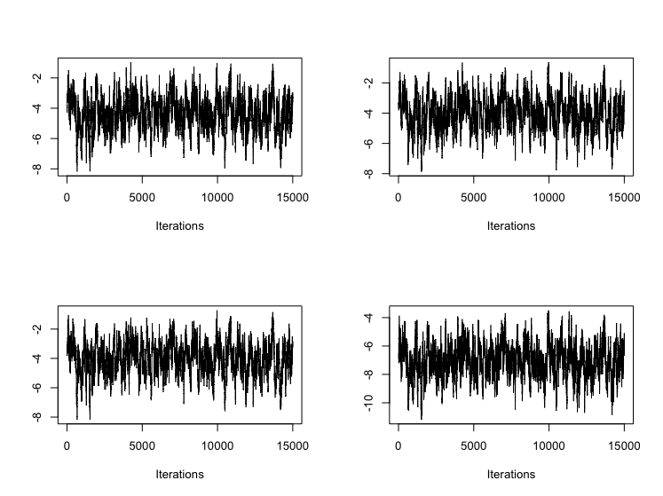

pMALA traceplots for the first four abilities.

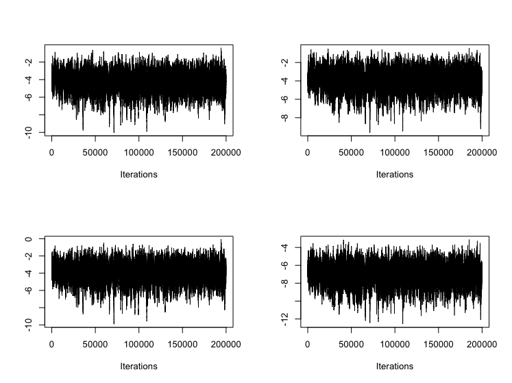

AM traceplots for the first four abilities.

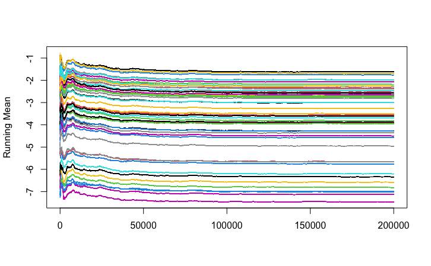

Running posterior means for the AM chain after burn-in.

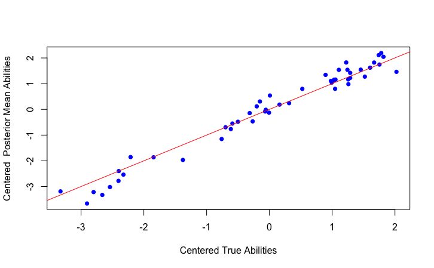

Centered true abilities against centered posterior mean estimates.

# Bibliography

[1] Livingstone, S. (2026). STAT0044 ICA2 2025/26.

[2] Jones, M. C., & Pewsey, A. (2009). Sinh-arcsinh distributions. Biometrika, 96(4), 761-780.

[3] Agresti, A. (2013). Categorical data analysis. John Wiley & Sons.

[4] Haario, H., Saksman, E., & Tamminen, J. (2001). An adaptive Metropolis algorithm.

[5] Roberts, G. (2011). An introduction to adaptive MCMC. [Link to the Slides](https://warwick.ac.uk/fac/sci/maths/research/miraw/days/montecarlo/abstracts/adaptivemiraw11_roberts.pdf)